# TA SESSION (University of Chicago)

- **Topic**: Logistic Regression
- **Written By:** Devanshi Verma
- **Source**: https://github.com/thisisdevanshi/DataMining-FinalProject
- **Goal**: Whether a new customer will do a new booking or not?
- **Link**:https://www.kaggle.com/c/airbnb-recruiting-new-user-bookings/overview/description

### 1.1 Importing the files and loading the dataset

```python
#loading the libraries
import pandas as pd
import numpy as np
import matplotlib.pyplot as plt
import seaborn as sns
```

```python
train_users = pd.read_csv("../Data/train_users_2.csv")
test_users = pd.read_csv("../Data/test_users.csv")
sessions= pd.read_csv("../Data/sessions.csv")
countries =pd.read_csv("../Data/countries.csv")
age_gender_bkts = pd.read_csv("../Data/age_gender_bkts.csv")
sample_submission=pd.read_csv("../Data/sample_submission_NDF.csv")
```

```python
#converting the date values to datetime
train_users['date_account_created'] = pd.to_datetime(train_users['date_account_created'])
train_users['date_first_booking'] = pd.to_datetime(train_users['date_first_booking'])
train_users['timestamp_first_active'] = pd.to_datetime(train_users['timestamp_first_active'], format='%Y%m%d%H%M%S')
test_users['date_first_booking'] = pd.to_datetime(test_users['date_first_booking'])
test_users['date_account_created'] = pd.to_datetime(test_users['date_account_created'])
test_users['timestamp_first_active'] = pd.to_datetime(test_users['timestamp_first_active'], format='%Y%m%d%H%M%S')
train_users.head()
test_users.head()
```

|  | id | date_account_created | timestamp_first_active | date_first_booking | gender | age | signup_method | signup_flow | language | affiliate_channel | affiliate_provider | first_affiliate_tracked | signup_app | first_device_type | first_browser |
| --- | --- | --- | --- | --- | --- | --- | --- | --- | --- | --- | --- | --- | --- | --- | --- |
| 0 | 5uwns89zht | 2014-07-01 | 2014-07-01 00:00:06 | NaT | FEMALE | 35.0 | facebook | 0 | en | direct | direct | untracked | Moweb | iPhone | Mobile Safari |
| 1 | jtl0dijy2j | 2014-07-01 | 2014-07-01 00:00:51 | NaT | -unknown- | NaN | basic | 0 | en | direct | direct | untracked | Moweb | iPhone | Mobile Safari |
| 2 | xx0ulgorjt | 2014-07-01 | 2014-07-01 00:01:48 | NaT | -unknown- | NaN | basic | 0 | en | direct | direct | linked | Web | Windows Desktop | Chrome |
| 3 | 6c6puo6ix0 | 2014-07-01 | 2014-07-01 00:02:15 | NaT | -unknown- | NaN | basic | 0 | en | direct | direct | linked | Web | Windows Desktop | IE |
| 4 | czqhjk3yfe | 2014-07-01 | 2014-07-01 00:03:05 | NaT | -unknown- | NaN | basic | 0 | en | direct | direct | untracked | Web | Mac Desktop | Safari |

```python
sessions.head()
```

|  | user_id | action | action_type | action_detail | device_type | secs_elapsed |
| --- | --- | --- | --- | --- | --- | --- |
| 0 | d1mm9tcy42 | lookup | NaN | NaN | Windows Desktop | 319.0 |
| 1 | d1mm9tcy42 | search_results | click | view_search_results | Windows Desktop | 67753.0 |
| 2 | d1mm9tcy42 | lookup | NaN | NaN | Windows Desktop | 301.0 |
| 3 | d1mm9tcy42 | search_results | click | view_search_results | Windows Desktop | 22141.0 |
| 4 | d1mm9tcy42 | lookup | NaN | NaN | Windows Desktop | 435.0 |

```python
countries.head()
```

|  | country_destination | lat_destination | lng_destination | distance_km | destination_km2 | destination_language | language_levenshtein_distance |
| --- | --- | --- | --- | --- | --- | --- | --- |
| 0 | AU | -26.853388 | 133.275160 | 15297.7440 | 7741220.0 | eng | 0.00 |
| 1 | CA | 62.393303 | -96.818146 | 2828.1333 | 9984670.0 | eng | 0.00 |
| 2 | DE | 51.165707 | 10.452764 | 7879.5680 | 357022.0 | deu | 72.61 |
| 3 | ES | 39.896027 | -2.487694 | 7730.7240 | 505370.0 | spa | 92.25 |
| 4 | FR | 46.232193 | 2.209667 | 7682.9450 | 643801.0 | fra | 92.06 |

```python
age_gender_bkts.head()
```

|  | age_bucket | country_destination | gender | population_in_thousands | year |
| --- | --- | --- | --- | --- | --- |
| 0 | 100+ | AU | male | 1.0 | 2015.0 |
| 1 | 95-99 | AU | male | 9.0 | 2015.0 |
| 2 | 90-94 | AU | male | 47.0 | 2015.0 |
| 3 | 85-89 | AU | male | 118.0 | 2015.0 |
| 4 | 80-84 | AU | male | 199.0 | 2015.0 |

```python
sample_submission.head()
```

|  | id | country |
| --- | --- | --- |
| 0 | 5uwns89zht | NDF |
| 1 | jtl0dijy2j | NDF |
| 2 | xx0ulgorjt | NDF |
| 3 | 6c6puo6ix0 | NDF |
| 4 | czqhjk3yfe | NDF |

### 1.2 EDA

```python
#Function to get distribution graphs

def get_distr(feature):
    sns.set()
    plt.figure(figsize=(10,8))
    sns.barplot(train_users[feature].value_counts().index,train_users[feature].value_counts(),palette="husl")
```

**Gender**

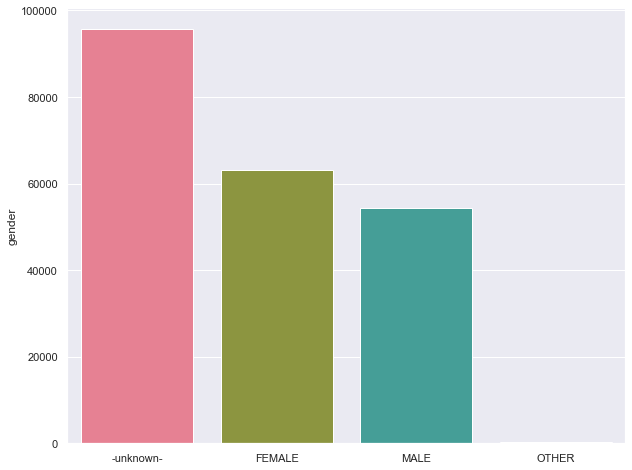

```python
get_distr('gender')
```

**Desination Distribution**

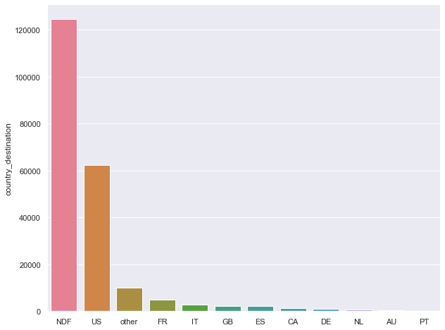

```python
get_distr('country_destination')
```

**Signup Method**

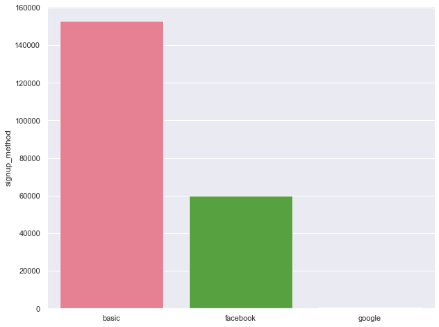

```python
get_distr('signup_method')
```

**age distribution**

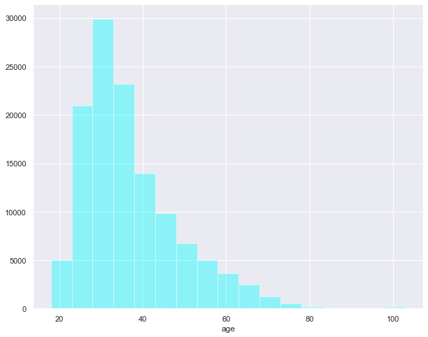

```python
#get_distr('age')
sns.set()
plt.figure(figsize=(10,8))
sns.distplot(train_users['age'],color="cyan",bins=np.arange(18,100+5,5),kde=False)
```

```python
train_users['age'].describe()
```

```
count    125461.000000
mean         49.668335
std         155.666612
min           1.000000
25%          28.000000
50%          34.000000
75%          43.000000
max        2014.000000
Name: age, dtype: float64
```

**language distribution**

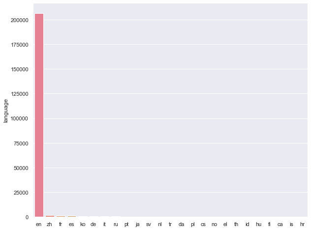

```python
get_distr('language')
```

**Signup app**

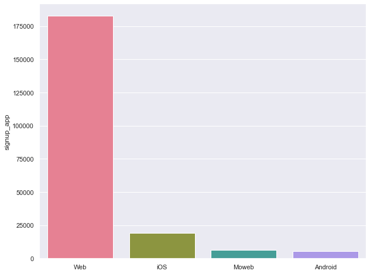

```python
get_distr('signup_app')
```

**first device type**

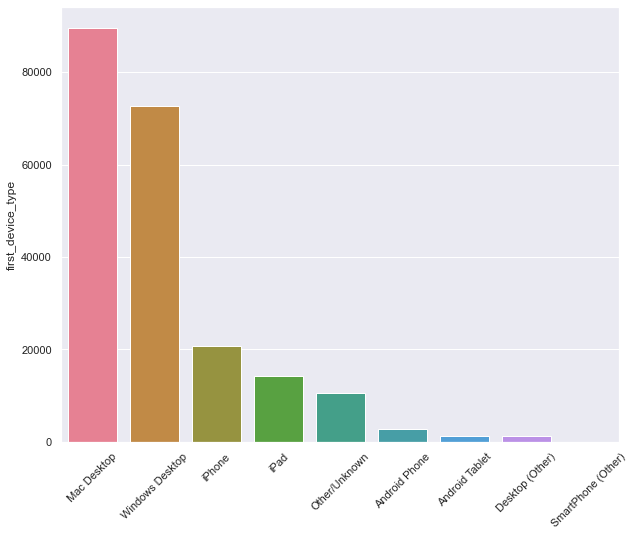

```python
sns.set()
plt.figure(figsize=(10,8))
sns.barplot(train_users['first_device_type'].value_counts().index,train_users['first_device_type'].value_counts(),palette="husl")
plt.xticks(rotation=45)
```

**When did the customers joined AirBnB?**

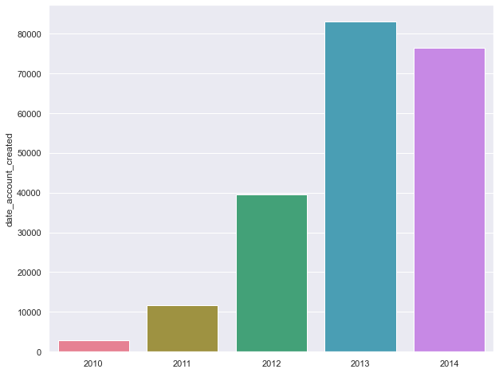

```python
sns.set()
plt.figure(figsize=(10,8))
sns.barplot(train_users['date_account_created'].dt.year.value_counts().index,train_users['date_account_created'].dt.year.value_counts(),palette="husl")
```

**When did customers do there first booking?**

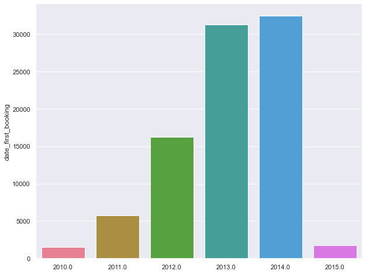

```python
sns.set()
plt.figure(figsize=(10,8))
sns.barplot(train_users['date_first_booking'].dt.year.value_counts().index,train_users['date_first_booking'].dt.year.value_counts(),palette="husl")
```

**How long were the customer sessions?**

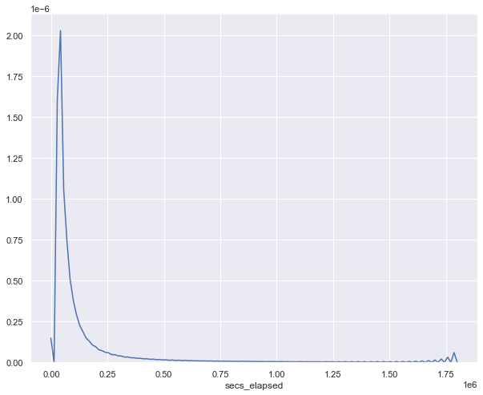

```python
sns.set()
plt.figure(figsize=(10,8))
sns.distplot(sessions['secs_elapsed'],hist=False)
```

```python
pd.DataFrame(sessions['secs_elapsed'].describe())
```

|  | secs_elapsed |
| --- | --- |
| count | 1.043171e+07 |
| mean | 1.940581e+04 |
| std | 8.888424e+04 |
| min | 0.000000e+00 |
| 25% | 2.290000e+02 |
| 50% | 1.147000e+03 |
| 75% | 8.444000e+03 |
| max | 1.799977e+06 |

**What is the other information about customer sessions?**

```python
sessions.head()
```

|  | user_id | action | action_type | action_detail | device_type | secs_elapsed |
| --- | --- | --- | --- | --- | --- | --- |
| 0 | d1mm9tcy42 | lookup | NaN | NaN | Windows Desktop | 319.0 |
| 1 | d1mm9tcy42 | search_results | click | view_search_results | Windows Desktop | 67753.0 |
| 2 | d1mm9tcy42 | lookup | NaN | NaN | Windows Desktop | 301.0 |
| 3 | d1mm9tcy42 | search_results | click | view_search_results | Windows Desktop | 22141.0 |
| 4 | d1mm9tcy42 | lookup | NaN | NaN | Windows Desktop | 435.0 |

**Understanding what information is in each of the columns for the sessions data**

```python
pd.DataFrame([len(sessions['action'].unique()),len(sessions['action_type'].unique()),
              len(sessions['action_detail'].unique()),len(sessions['device_type'].unique())])
```

|  | 0 |
| --- | --- |
| 0 | 360 |
| 1 | 11 |
| 2 | 156 |
| 3 | 14 |

**The action column has the most unique variables, but may create a very messy list of parameters. We will look at the parameters in action_type, action_detail and device_type, to see if any useful information is in there**

```python
pd.DataFrame(sessions.groupby("action").count().iloc[:,1])
```

| action | action_type |
| --- | --- |
| 10 | 3215 |
| 11 | 716 |
| 12 | 2209 |
| 15 | 1053 |
| about_us | 416 |
| ... | ... |
| weibo_signup_referral_finish | 45 |
| why_host | 180 |
| widget | 0 |
| wishlists | 1 |
| zendesk_login_jwt | 24 |

359 rows × 1 columns

```python
pd.DataFrame(sessions.groupby("action_type").count().iloc[:,1])
```

| action_type | action |
| --- | --- |
| -unknown- | 1031170 |
| booking_request | 18773 |
| booking_response | 4 |
| click | 1996183 |
| data | 2103770 |
| message_post | 7477 |
| modify | 1139 |
| partner_callback | 19132 |
| submit | 623357 |
| view | 3560902 |

```python
pd.DataFrame(sessions.groupby('action_detail').count().iloc[:,1])
```

| action_detail | action |
| --- | --- |
| -unknown- | 1031141 |
| account_notification_settings | 21802 |
| account_payment_methods | 1005 |
| account_payout_preferences | 4569 |
| account_privacy_settings | 1943 |
| ... | ... |
| wishlist_content_update | 706824 |
| wishlist_note | 961 |
| your_listings | 30980 |
| your_reservations | 1283 |
| your_trips | 38195 |

155 rows × 1 columns

```python
pd.DataFrame(sessions.groupby('device_type').count().iloc[:,1])
```

| device_type | action |
| --- | --- |
| -unknown- | 210489 |
| Android App Unknown Phone/Tablet | 272933 |
| Android Phone | 838038 |
| Blackberry | 972 |
| Chromebook | 22164 |
| Linux Desktop | 28097 |
| Mac Desktop | 3559217 |
| Opera Phone | 68 |
| Tablet | 139202 |
| Windows Desktop | 2629541 |
| Windows Phone | 2037 |
| iPad Tablet | 679169 |
| iPhone | 2098022 |
| iPodtouch | 8162 |

### Inference from the data given above

- In terms of gender, females are more active on AirBnB then main. And majority of the users havent specfied their gender
- A major chunk of people just join the website but don't book a destination(NDF). US is the most popular destination followed by other locations, france and italy.
- Majority of our users join via basic then via facebook
- In terms of users, we see high values in the range 20-40 peaking at ~30
- In terms of language major users english, followed by chinese and french
- Majority of the users signed up by Web followed by iOS
- An interesting trend is that major users signed up in 2013 whereas major bookings are done in 2014
- For the Sessions data, there is a large density at the median and a long tail, with a group of outliers near the max.
- The action column has the most unique variables, but may create a very messy list of parameters. We will look at the parameters in action_type, action_detail and device_type, to see if any useful information is in there.

### 1.3 Feature Engineering

```python
#Get dummies for action detail and device type
categorical_cols = ['action_detail','device_type']
sessions_dummies = pd.get_dummies(sessions[categorical_cols], drop_first=False)
#Add these columns to user ids
df_sessions=pd.concat([sessions['user_id'],sessions_dummies], axis=1)
#Group by summing variables for each user_id. This will give us the count of sessions for action_details and Device types
agg_sessions=df_sessions.groupby("user_id").sum()
#Aggregate the seconds elapsed for each session into mean, count and max
secs_elapsed=sessions.groupby(['user_id']).agg({'secs_elapsed': ['mean', 'count','max']})
#Merge all info together
sessions_complete=pd.merge(secs_elapsed,agg_sessions, on=["user_id"])
sessions_complete=sessions_complete.reset_index()
sessions_complete.rename(columns={'user_id':'id'},inplace=True)
#imputing 0 for NaN as we don't have that data for the user
sessions_complete.fillna(0,inplace=True)
sessions_complete.head()
```

|  | id | (secs_elapsed, mean) | (secs_elapsed, count) | (secs_elapsed, max) | action_detail_-unknown- | action_detail_account_notification_settings | action_detail_account_payment_methods | action_detail_account_payout_preferences | action_detail_account_privacy_settings | action_detail_account_transaction_history | ... | device_type_Chromebook | device_type_Linux Desktop | device_type_Mac Desktop | device_type_Opera Phone | device_type_Tablet | device_type_Windows Desktop | device_type_Windows Phone | device_type_iPad Tablet | device_type_iPhone | device_type_iPodtouch |
| --- | --- | --- | --- | --- | --- | --- | --- | --- | --- | --- | --- | --- | --- | --- | --- | --- | --- | --- | --- | --- | --- |
| 0 | 00023iyk9l | 22253.743590 | 39 | 567165.0 | 0.0 | 0.0 | 0.0 | 0.0 | 0.0 | 0.0 | ... | 0.0 | 0.0 | 36.0 | 0.0 | 0.0 | 0.0 | 0.0 | 0.0 | 4.0 | 0.0 |
| 1 | 0010k6l0om | 9460.370968 | 62 | 127898.0 | 5.0 | 0.0 | 0.0 | 0.0 | 0.0 | 0.0 | ... | 0.0 | 0.0 | 63.0 | 0.0 | 0.0 | 0.0 | 0.0 | 0.0 | 0.0 | 0.0 |
| 2 | 001wyh0pz8 | 3179.382022 | 89 | 50548.0 | 6.0 | 0.0 | 0.0 | 0.0 | 0.0 | 0.0 | ... | 0.0 | 0.0 | 0.0 | 0.0 | 0.0 | 0.0 | 0.0 | 0.0 | 0.0 | 0.0 |
| 3 | 0028jgx1x1 | 9900.333333 | 30 | 84636.0 | 1.0 | 0.0 | 0.0 | 0.0 | 0.0 | 0.0 | ... | 0.0 | 0.0 | 0.0 | 0.0 | 0.0 | 0.0 | 0.0 | 0.0 | 0.0 | 0.0 |
| 4 | 002qnbzfs5 | 8232.335025 | 788 | 1418284.0 | 184.0 | 0.0 | 0.0 | 0.0 | 0.0 | 0.0 | ... | 0.0 | 0.0 | 0.0 | 0.0 | 0.0 | 0.0 | 0.0 | 0.0 | 775.0 | 0.0 |

5 rows × 173 columns

- **Dealing with test and train data together to get same number of features after one hot encoding**

```python
completedata=pd.concat((train_users.drop(['country_destination'], axis=1), test_users), axis = 0, ignore_index= True)
completedata.head()
```

|  | id | date_account_created | timestamp_first_active | date_first_booking | gender | age | signup_method | signup_flow | language | affiliate_channel | affiliate_provider | first_affiliate_tracked | signup_app | first_device_type | first_browser |
| --- | --- | --- | --- | --- | --- | --- | --- | --- | --- | --- | --- | --- | --- | --- | --- |
| 0 | gxn3p5htnn | 2010-06-28 | 2009-03-19 04:32:55 | NaT | -unknown- | NaN | facebook | 0 | en | direct | direct | untracked | Web | Mac Desktop | Chrome |
| 1 | 820tgsjxq7 | 2011-05-25 | 2009-05-23 17:48:09 | NaT | MALE | 38.0 | facebook | 0 | en | seo | google | untracked | Web | Mac Desktop | Chrome |
| 2 | 4ft3gnwmtx | 2010-09-28 | 2009-06-09 23:12:47 | 2010-08-02 | FEMALE | 56.0 | basic | 3 | en | direct | direct | untracked | Web | Windows Desktop | IE |
| 3 | bjjt8pjhuk | 2011-12-05 | 2009-10-31 06:01:29 | 2012-09-08 | FEMALE | 42.0 | facebook | 0 | en | direct | direct | untracked | Web | Mac Desktop | Firefox |
| 4 | 87mebub9p4 | 2010-09-14 | 2009-12-08 06:11:05 | 2010-02-18 | -unknown- | 41.0 | basic | 0 | en | direct | direct | untracked | Web | Mac Desktop | Chrome |

```python
#Adding sessions data to it
completedata=completedata.merge(sessions_complete,how="left",left_on="id",right_on="id")
completedata
```

|  | id | date_account_created | timestamp_first_active | date_first_booking | gender | age | signup_method | signup_flow | language | affiliate_channel | ... | device_type_Chromebook | device_type_Linux Desktop | device_type_Mac Desktop | device_type_Opera Phone | device_type_Tablet | device_type_Windows Desktop | device_type_Windows Phone | device_type_iPad Tablet | device_type_iPhone | device_type_iPodtouch |
| --- | --- | --- | --- | --- | --- | --- | --- | --- | --- | --- | --- | --- | --- | --- | --- | --- | --- | --- | --- | --- | --- |
| 0 | gxn3p5htnn | 2010-06-28 | 2009-03-19 04:32:55 | NaT | -unknown- | NaN | facebook | 0 | en | direct | ... | NaN | NaN | NaN | NaN | NaN | NaN | NaN | NaN | NaN | NaN |
| 1 | 820tgsjxq7 | 2011-05-25 | 2009-05-23 17:48:09 | NaT | MALE | 38.0 | facebook | 0 | en | seo | ... | NaN | NaN | NaN | NaN | NaN | NaN | NaN | NaN | NaN | NaN |
| 2 | 4ft3gnwmtx | 2010-09-28 | 2009-06-09 23:12:47 | 2010-08-02 | FEMALE | 56.0 | basic | 3 | en | direct | ... | NaN | NaN | NaN | NaN | NaN | NaN | NaN | NaN | NaN | NaN |
| 3 | bjjt8pjhuk | 2011-12-05 | 2009-10-31 06:01:29 | 2012-09-08 | FEMALE | 42.0 | facebook | 0 | en | direct | ... | NaN | NaN | NaN | NaN | NaN | NaN | NaN | NaN | NaN | NaN |
| 4 | 87mebub9p4 | 2010-09-14 | 2009-12-08 06:11:05 | 2010-02-18 | -unknown- | 41.0 | basic | 0 | en | direct | ... | NaN | NaN | NaN | NaN | NaN | NaN | NaN | NaN | NaN | NaN |
| ... | ... | ... | ... | ... | ... | ... | ... | ... | ... | ... | ... | ... | ... | ... | ... | ... | ... | ... | ... | ... | ... |
| 275542 | cv0na2lf5a | 2014-09-30 | 2014-09-30 23:52:32 | NaT | -unknown- | 31.0 | basic | 0 | en | direct | ... | 0.0 | 0.0 | 0.0 | 0.0 | 0.0 | 89.0 | 0.0 | 0.0 | 4.0 | 0.0 |
| 275543 | zp8xfonng8 | 2014-09-30 | 2014-09-30 23:53:06 | NaT | -unknown- | NaN | basic | 23 | ko | direct | ... | 0.0 | 0.0 | 0.0 | 0.0 | 0.0 | 0.0 | 0.0 | 0.0 | 0.0 | 0.0 |
| 275544 | fa6260ziny | 2014-09-30 | 2014-09-30 23:54:08 | NaT | -unknown- | NaN | basic | 0 | de | direct | ... | 0.0 | 0.0 | 0.0 | 0.0 | 0.0 | 78.0 | 0.0 | 0.0 | 0.0 | 0.0 |
| 275545 | 87k0fy4ugm | 2014-09-30 | 2014-09-30 23:54:30 | NaT | -unknown- | NaN | basic | 0 | en | sem-brand | ... | 0.0 | 0.0 | 11.0 | 0.0 | 0.0 | 0.0 | 0.0 | 0.0 | 4.0 | 0.0 |
| 275546 | 9uqfg8txu3 | 2014-09-30 | 2014-09-30 23:59:01 | NaT | FEMALE | 49.0 | basic | 0 | en | other | ... | 0.0 | 0.0 | 0.0 | 0.0 | 0.0 | 14.0 | 0.0 | 0.0 | 0.0 | 0.0 |

275547 rows × 187 columns

```python
#Age of 2014 isn't possible and 1 is also not possible so capping the age and converting them to Nan'S
completedata.loc[completedata.age > 100, 'age'] = np.nan
completedata.loc[completedata.age < 13, 'age'] = np.nan
```

```python
#Finding the Nan's by a user
completedata['nans'] = np.sum([
    (completedata['age'] == np.nan),
    (completedata['gender'] == '-unknown-'),
    (completedata['language'] == '-unknown-'),
    (completedata['first_affiliate_tracked'] == 'untracked'),
    (completedata['first_browser'] == '-unknown-')
], axis=0)
```

```python
#Get Weekday names
completedata["weekday_account_created"]=completedata["date_account_created"].dt.day_name
```

```python
completedata.head()
```

|  | id | date_account_created | timestamp_first_active | date_first_booking | gender | age | signup_method | signup_flow | language | affiliate_channel | ... | device_type_Mac Desktop | device_type_Opera Phone | device_type_Tablet | device_type_Windows Desktop | device_type_Windows Phone | device_type_iPad Tablet | device_type_iPhone | device_type_iPodtouch | nans | weekday_account_created |
| --- | --- | --- | --- | --- | --- | --- | --- | --- | --- | --- | --- | --- | --- | --- | --- | --- | --- | --- | --- | --- | --- |
| 0 | gxn3p5htnn | 2010-06-28 | 2009-03-19 04:32:55 | NaT | -unknown- | NaN | facebook | 0 | en | direct | ... | NaN | NaN | NaN | NaN | NaN | NaN | NaN | NaN | 2 | <bound method PandasDelegate._add_delegate_acc... |
| 1 | 820tgsjxq7 | 2011-05-25 | 2009-05-23 17:48:09 | NaT | MALE | 38.0 | facebook | 0 | en | seo | ... | NaN | NaN | NaN | NaN | NaN | NaN | NaN | NaN | 1 | <bound method PandasDelegate._add_delegate_acc... |
| 2 | 4ft3gnwmtx | 2010-09-28 | 2009-06-09 23:12:47 | 2010-08-02 | FEMALE | 56.0 | basic | 3 | en | direct | ... | NaN | NaN | NaN | NaN | NaN | NaN | NaN | NaN | 1 | <bound method PandasDelegate._add_delegate_acc... |
| 3 | bjjt8pjhuk | 2011-12-05 | 2009-10-31 06:01:29 | 2012-09-08 | FEMALE | 42.0 | facebook | 0 | en | direct | ... | NaN | NaN | NaN | NaN | NaN | NaN | NaN | NaN | 1 | <bound method PandasDelegate._add_delegate_acc... |
| 4 | 87mebub9p4 | 2010-09-14 | 2009-12-08 06:11:05 | 2010-02-18 | -unknown- | 41.0 | basic | 0 | en | direct | ... | NaN | NaN | NaN | NaN | NaN | NaN | NaN | NaN | 2 | <bound method PandasDelegate._add_delegate_acc... |

5 rows × 189 columns

```python
#Dropping columns
completedata=completedata.drop(['id'],axis=1)
completedata=completedata.drop(['date_account_created'],axis=1)
completedata=completedata.drop(['date_first_booking'],axis=1)
completedata=completedata.drop(['timestamp_first_active'],axis=1)
```

```python
categorical_features=['gender','signup_method','signup_flow','language','affiliate_channel','affiliate_provider','first_affiliate_tracked','signup_app',
                    'first_device_type','first_browser','weekday_account_created']
numerical_features=[i for i in completedata.columns if i not in categorical_features ]
from sklearn.preprocessing import StandardScaler
scaled_features = completedata.copy()
features = completedata[numerical_features]
features = StandardScaler().fit_transform(features.values)
scaled_features[numerical_features] = features
completedata=scaled_features
completedata.head()
```

|  | gender | age | signup_method | signup_flow | language | affiliate_channel | affiliate_provider | first_affiliate_tracked | signup_app | first_device_type | ... | device_type_Mac Desktop | device_type_Opera Phone | device_type_Tablet | device_type_Windows Desktop | device_type_Windows Phone | device_type_iPad Tablet | device_type_iPhone | device_type_iPodtouch | nans | weekday_account_created |
| --- | --- | --- | --- | --- | --- | --- | --- | --- | --- | --- | --- | --- | --- | --- | --- | --- | --- | --- | --- | --- | --- |
| 0 | -unknown- | NaN | facebook | 0 | en | direct | direct | untracked | Web | Mac Desktop | ... | NaN | NaN | NaN | NaN | NaN | NaN | NaN | NaN | 0.958469 | <bound method PandasDelegate._add_delegate_acc... |
| 1 | MALE | 0.166754 | facebook | 0 | en | seo | google | untracked | Web | Mac Desktop | ... | NaN | NaN | NaN | NaN | NaN | NaN | NaN | NaN | -0.169994 | <bound method PandasDelegate._add_delegate_acc... |
| 2 | FEMALE | 1.710013 | basic | 3 | en | direct | direct | untracked | Web | Windows Desktop | ... | NaN | NaN | NaN | NaN | NaN | NaN | NaN | NaN | -0.169994 | <bound method PandasDelegate._add_delegate_acc... |
| 3 | FEMALE | 0.509701 | facebook | 0 | en | direct | direct | untracked | Web | Mac Desktop | ... | NaN | NaN | NaN | NaN | NaN | NaN | NaN | NaN | -0.169994 | <bound method PandasDelegate._add_delegate_acc... |
| 4 | -unknown- | 0.423964 | basic | 0 | en | direct | direct | untracked | Web | Mac Desktop | ... | NaN | NaN | NaN | NaN | NaN | NaN | NaN | NaN | 0.958469 | <bound method PandasDelegate._add_delegate_acc... |

5 rows × 185 columns

```python
#Making singup flow catgorical
completedata['signup_flow']=completedata['signup_flow'].astype('str')

def create_dummyvariables(data,columname):
    col=pd.get_dummies(data[columname], prefix=columname).iloc[:, 1:] #Taking all columns after the 0th column for k-1 dummy variables
    data=pd.concat([data, col], axis=1)
    data=data.drop([columname],axis=1)
    return data

categorical_features=['gender','signup_method','signup_flow','language','affiliate_channel','affiliate_provider','first_affiliate_tracked','signup_app',
                    'first_device_type','first_browser','weekday_account_created']

for i in categorical_features:
    completedata=create_dummyvariables(completedata,i)

completedata.head()
```

|  | age | (secs_elapsed, mean) | (secs_elapsed, count) | (secs_elapsed, max) | action_detail_-unknown- | action_detail_account_notification_settings | action_detail_account_payment_methods | action_detail_account_payout_preferences | action_detail_account_privacy_settings | action_detail_account_transaction_history | ... | first_browser_Silk | first_browser_SiteKiosk | first_browser_SlimBrowser | first_browser_Sogou Explorer | first_browser_Stainless | first_browser_TenFourFox | first_browser_TheWorld Browser | first_browser_UC Browser | first_browser_Yandex.Browser | first_browser_wOSBrowser |
| --- | --- | --- | --- | --- | --- | --- | --- | --- | --- | --- | --- | --- | --- | --- | --- | --- | --- | --- | --- | --- | --- |
| 0 | NaN | NaN | NaN | NaN | NaN | NaN | NaN | NaN | NaN | NaN | ... | 0 | 0 | 0 | 0 | 0 | 0 | 0 | 0 | 0 | 0 |
| 1 | 0.166754 | NaN | NaN | NaN | NaN | NaN | NaN | NaN | NaN | NaN | ... | 0 | 0 | 0 | 0 | 0 | 0 | 0 | 0 | 0 | 0 |
| 2 | 1.710013 | NaN | NaN | NaN | NaN | NaN | NaN | NaN | NaN | NaN | ... | 0 | 0 | 0 | 0 | 0 | 0 | 0 | 0 | 0 | 0 |
| 3 | 0.509701 | NaN | NaN | NaN | NaN | NaN | NaN | NaN | NaN | NaN | ... | 0 | 0 | 0 | 0 | 0 | 0 | 0 | 0 | 0 | 0 |
| 4 | 0.423964 | NaN | NaN | NaN | NaN | NaN | NaN | NaN | NaN | NaN | ... | 0 | 0 | 0 | 0 | 0 | 0 | 0 | 0 | 0 | 0 |

5 rows × 317 columns

```python
#Finding Null Entries
print("The null values in the dataset are:")
df=pd.DataFrame(np.sum(completedata.isnull(),axis=0))
df[[0]]=(df[[0]]/completedata.shape[0])*100
df
```

```
The null values in the dataset are:
```

|  | 0 |
| --- | --- |
| age | 43.410017 |
| (secs_elapsed, mean) | 50.831256 |
| (secs_elapsed, count) | 50.831256 |
| (secs_elapsed, max) | 50.831256 |
| action_detail_-unknown- | 50.831256 |
| ... | ... |
| first_browser_TenFourFox | 0.000000 |
| first_browser_TheWorld Browser | 0.000000 |
| first_browser_UC Browser | 0.000000 |
| first_browser_Yandex.Browser | 0.000000 |
| first_browser_wOSBrowser | 0.000000 |

317 rows × 1 columns

```python
#imputing mean age
completedata['age'].fillna(completedata['age'].mean(),inplace=True)
#adding 0's to sessions data
completedata.fillna(0,inplace=True)
```

```python
#removing any duplicated column
completedata = completedata.loc[:,~completedata.columns.duplicated()]
completedata.head()
```

|  | age | (secs_elapsed, mean) | (secs_elapsed, count) | (secs_elapsed, max) | action_detail_-unknown- | action_detail_account_notification_settings | action_detail_account_payment_methods | action_detail_account_payout_preferences | action_detail_account_privacy_settings | action_detail_account_transaction_history | ... | first_browser_Silk | first_browser_SiteKiosk | first_browser_SlimBrowser | first_browser_Sogou Explorer | first_browser_Stainless | first_browser_TenFourFox | first_browser_TheWorld Browser | first_browser_UC Browser | first_browser_Yandex.Browser | first_browser_wOSBrowser |
| --- | --- | --- | --- | --- | --- | --- | --- | --- | --- | --- | --- | --- | --- | --- | --- | --- | --- | --- | --- | --- | --- |
| 0 | -7.739727e-15 | 0.0 | 0.0 | 0.0 | 0.0 | 0.0 | 0.0 | 0.0 | 0.0 | 0.0 | ... | 0 | 0 | 0 | 0 | 0 | 0 | 0 | 0 | 0 | 0 |
| 1 | 1.667540e-01 | 0.0 | 0.0 | 0.0 | 0.0 | 0.0 | 0.0 | 0.0 | 0.0 | 0.0 | ... | 0 | 0 | 0 | 0 | 0 | 0 | 0 | 0 | 0 | 0 |
| 2 | 1.710013e+00 | 0.0 | 0.0 | 0.0 | 0.0 | 0.0 | 0.0 | 0.0 | 0.0 | 0.0 | ... | 0 | 0 | 0 | 0 | 0 | 0 | 0 | 0 | 0 | 0 |
| 3 | 5.097006e-01 | 0.0 | 0.0 | 0.0 | 0.0 | 0.0 | 0.0 | 0.0 | 0.0 | 0.0 | ... | 0 | 0 | 0 | 0 | 0 | 0 | 0 | 0 | 0 | 0 |
| 4 | 4.239639e-01 | 0.0 | 0.0 | 0.0 | 0.0 | 0.0 | 0.0 | 0.0 | 0.0 | 0.0 | ... | 0 | 0 | 0 | 0 | 0 | 0 | 0 | 0 | 0 | 0 |

5 rows × 317 columns

```python
X=completedata.loc[0:train_users.shape[0]-1,:]
test_df=completedata.loc[train_users.shape[0]:,:]
```

```python
#getting label for countries
from sklearn.preprocessing import LabelEncoder
le = LabelEncoder()
y=le.fit_transform(train_users['country_destination'])
y.shape
```

```
(213451,)
```

```python
#The number of rows and columns for X
print("The shape of X is {}".format(X.shape))
```

```
The shape of X is (213451, 317)
```

### 1.4 Evalutation Metric by Kaggle

```python
"""Metrics to compute the model performance."""

import numpy as np
from sklearn.preprocessing import LabelBinarizer
from sklearn.metrics import make_scorer


def dcg_score(y_true, y_score, k=5):
    order = np.argsort(y_score)[::-1]
    y_true = np.take(y_true, order[:k])

    gain = 2 ** y_true - 1

    discounts = np.log2(np.arange(len(y_true)) + 2)
    return np.sum(gain / discounts)


def ndcg_score(ground_truth, predictions, k=5):
    lb = LabelBinarizer()
    lb.fit(range(len(predictions) + 1))
    T = lb.transform(ground_truth)

    scores = []

    # Iterate over each y_true and compute the DCG score
    for y_true, y_score in zip(T, predictions):
        actual = dcg_score(y_true, y_score, k)
        best = dcg_score(y_true, y_true, k)
        score = float(actual) / float(best)
        scores.append(score)

    return np.mean(scores)


ndcg_scorer = make_scorer(ndcg_score, needs_proba=True, k=5)
```

### 1.5 Understanding What makes a new user books a place

y=7 implies NDF

- y=0 if y =7 i.e Not Booked
- y=1 if y !=7 i.e Booked

```python
y_new=np.array([0 if i==7 else 1 for i in y])
#dividing the data into train and test
from sklearn.model_selection import train_test_split
X_train_new, X_test_new, y_train_new, y_test_new = train_test_split( X, y_new, test_size=0.3, random_state=42,stratify=y)
```

**Fitting a logistic model to find out what makes a user book**

```python
from sklearn.linear_model import LogisticRegression
logreg = LogisticRegression(random_state=42,max_iter=12000)
logreg.fit(X_train_new, y_train_new)

y_pred = logreg.predict(X_test_new)
print('Accuracy of Test logistic regression classifier on test set: {:.2f}'.format(logreg.score(X_test_new, y_test_new)))
```

```
Accuracy of Test logistic regression classifier on test set: 0.68
```

**Finding out the important features**

```
The most important features in the model are:
```

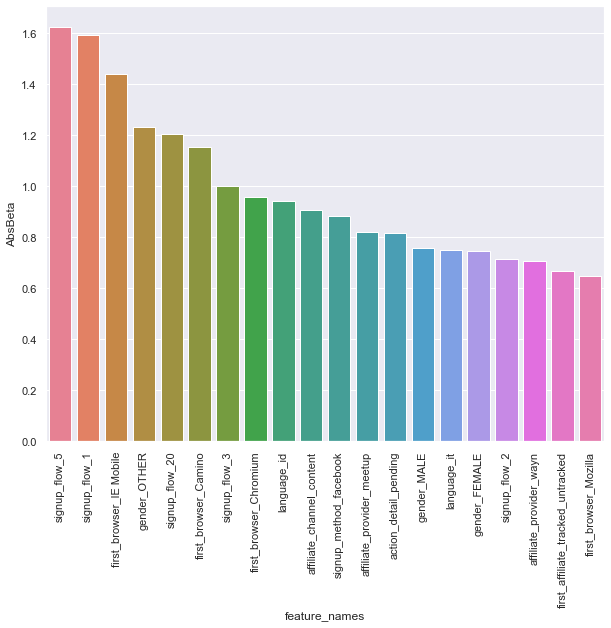

```python
#Getting best coefficiants
feature_imp=logreg.coef_
coef_table=pd.DataFrame({"feature_names":X_train_new.columns,"Beta":feature_imp[0],"AbsBeta":abs(feature_imp[0])})
#Get the sorted values
coef_table=coef_table.sort_values(by='AbsBeta',ascending=False)
print("The most important features in the model are: \n")
coef_table=coef_table.iloc[0:20,:]

#plotting the values
sns.set()
plt.figure(figsize=(10,8))
sns.barplot(coef_table['feature_names'],coef_table['AbsBeta'],palette="husl")
plt.xticks(rotation=90)
```

### 1.6.2 Fitting a Logistic Model

```python
from sklearn.linear_model import LogisticRegression
clf = LogisticRegression(max_iter=12000)
clf.fit(X_train, y_train)
lr_pred = clf.predict(X_test)
print('Accuracy of Logisitic Classifier on test set: {:.2f}'.format(clf.score(X_test, y_test)))
```

```
Accuracy of Logisitic Classifier on test set: 0.62
```

```python
print('Accuracy of Logistic Classifier on Train set: {:.2f}'.format(clf.score(X_train, y_train)))
print('Accuracy of Logistic Classifier on Test set: {:.2f}'.format(clf.score(X_test, y_test)))
```

```
Accuracy of Logistic Classifier on Train set: 0.62
Accuracy of Logistic Classifier on Test set: 0.62
```